# Experiments with groups of stations: using kmeans for 3 clusters with catchment_size and fpg as params

FBK

9 januar 2017

```
## [1] "st_selection_1"
```

```
##  [1]  10  11  12  13  16  17  18  20  21  25  38  39  43  49  50  57  77
## [18] 116 117 144 149 152 153 160 161 168 174 180 188 189 202 203 208 214
## [35] 222 231 233 234 235 237 240 242 244 245 246 247 251 252 254 256 289
## [52] 298
```

```
## [1] "st_selection_2"
```

```
##  [1]   1  15  23  27  34  40  42  45  46  56  58 111 119 120 121 122 123
## [18] 124 150 156 164 166 175 176 197 224 229 230 288 290
```

```
## [1] "st_selection_3"
```

```
##  [1]  14  19  22  28  29  31  32  33  41  44  59  60  61  62  63  64  65
## [18]  66  67  68  69  74  75  78  80  81  82  83  84  85  88  91  92  93
## [35]  94  96  97 102 103 105 106 107 108 109 110 112 125 126 127 128 130
## [52] 132 133 134 136 138 140 141 142 145 147 157 163 165 171 179 182 185
## [69] 201 204 216 220 227 262 279 283 291
```

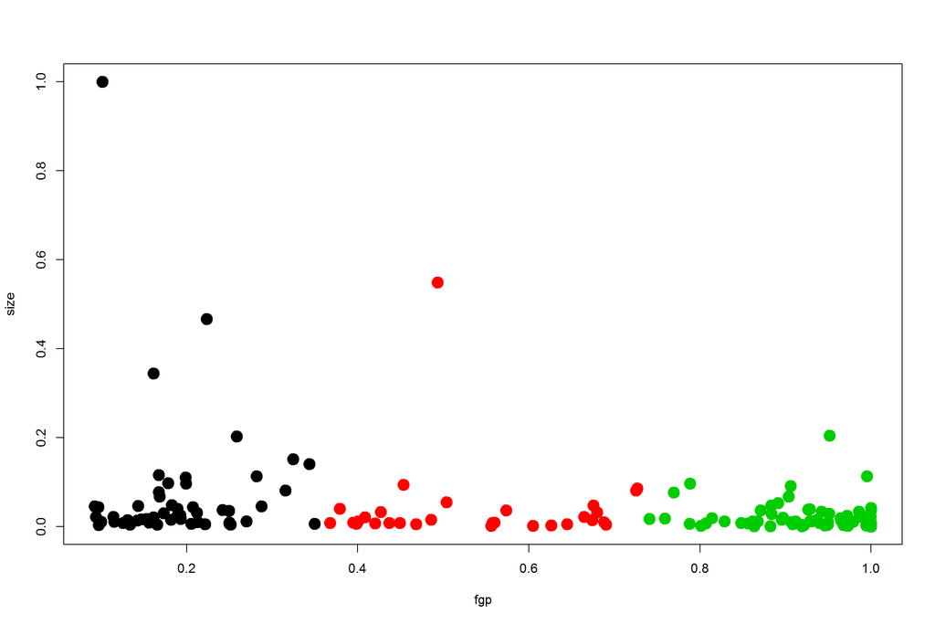

[figure not shown]

[figure not shown]

[figure not shown]

## BS

[1] “BS” [1] 2 [1] 10 11 12 13 16 17 18 20 21 25 38 39 43 49 50 57 77 [18] 116 117 144 149 152 153 160 161 168 174 180 188 189 202 203 208 214 [35] 222 231 233 234 235 237 240 242 244 245 246 247 251 252 254 256 289 [52] 298 [1] “done printint”

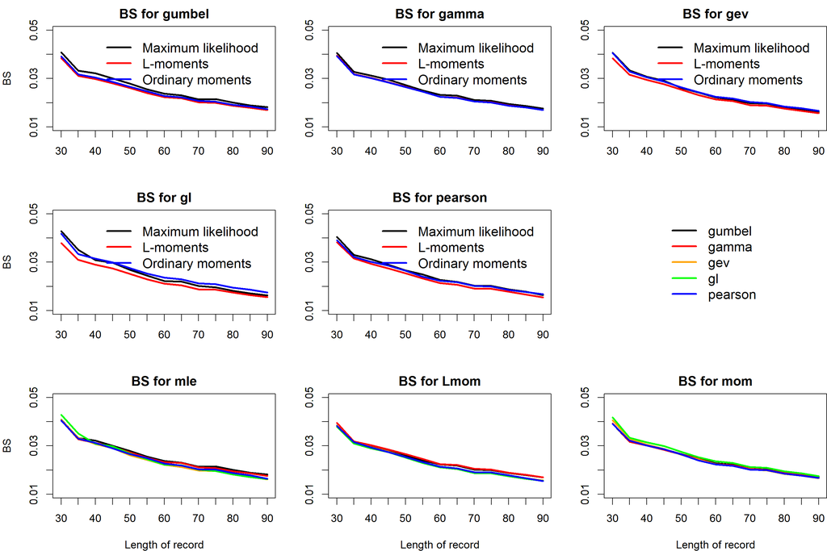

[1] “BS” [1] 2 [1] 1 15 23 27 34 40 42 45 46 56 58 111 119 120 121 122 123 [18] 124 150 156 164 166 175 176 197 224 229 230 288 290 [1] “done printint”

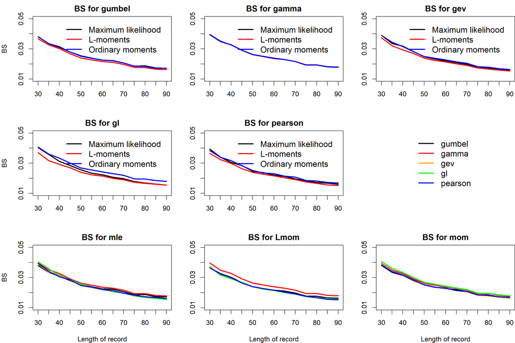

[1] “BS” [1] 2 [1] 14 19 22 28 29 31 32 33 41 44 59 60 61 62 63 64 65 [18] 66 67 68 69 74 75 78 80 81 82 83 84 85 88 91 92 93 [35] 94 96 97 102 103 105 106 107 108 109 110 112 125 126 127 128 130 [52] 132 133 134 136 138 140 141 142 145 147 157 163 165 171 179 182 185 [69] 201 204 216 220 227 262 279 283 291 [1] “done printint”

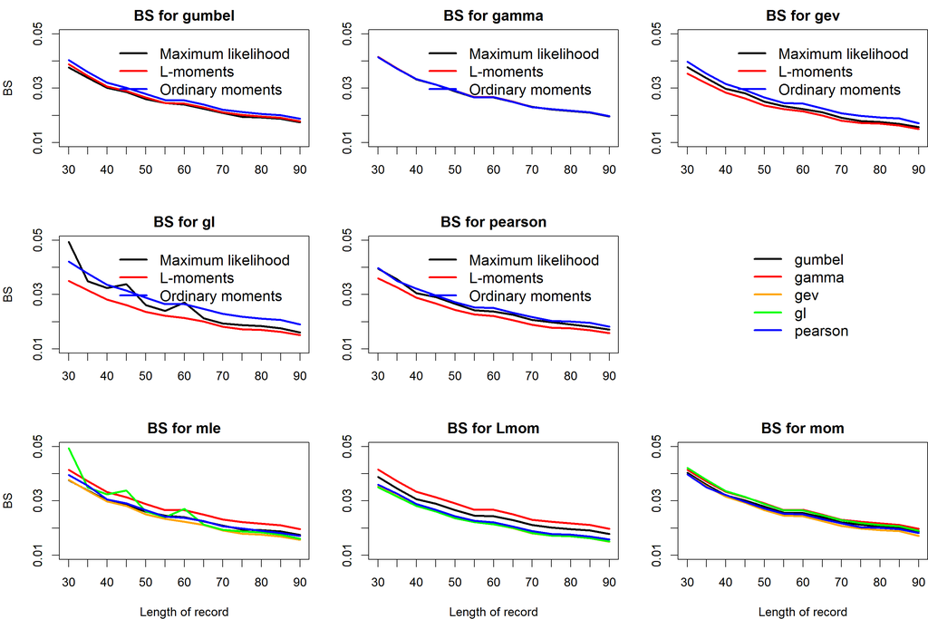

## Return levels

#### RL 10y

[1] “r.levels” [1] 10 [1] 10 11 12 13 16 17 18 20 21 25 38 39 43 49 50 57 77 [18] 116 117 144 149 152 153 160 161 168 174 180 188 189 202 203 208 214 [35] 222 231 233 234 235 237 240 242 244 245 246 247 251 252 254 256 289 [52] 298 [1] “done printint”

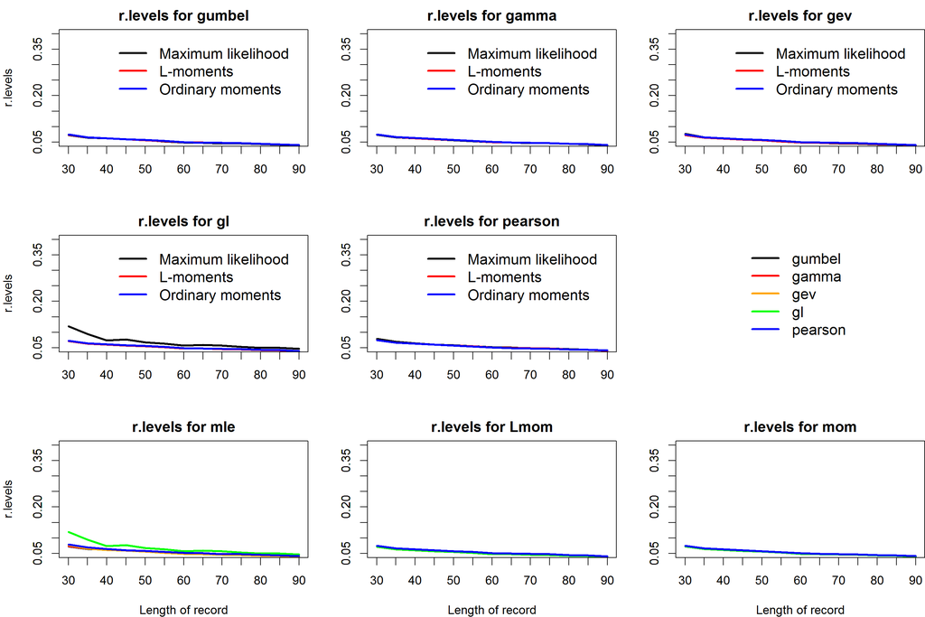

[1] “r.levels” [1] 10 [1] 1 15 23 27 34 40 42 45 46 56 58 111 119 120 121 122 123 [18] 124 150 156 164 166 175 176 197 224 229 230 288 290 [1] “done printint”

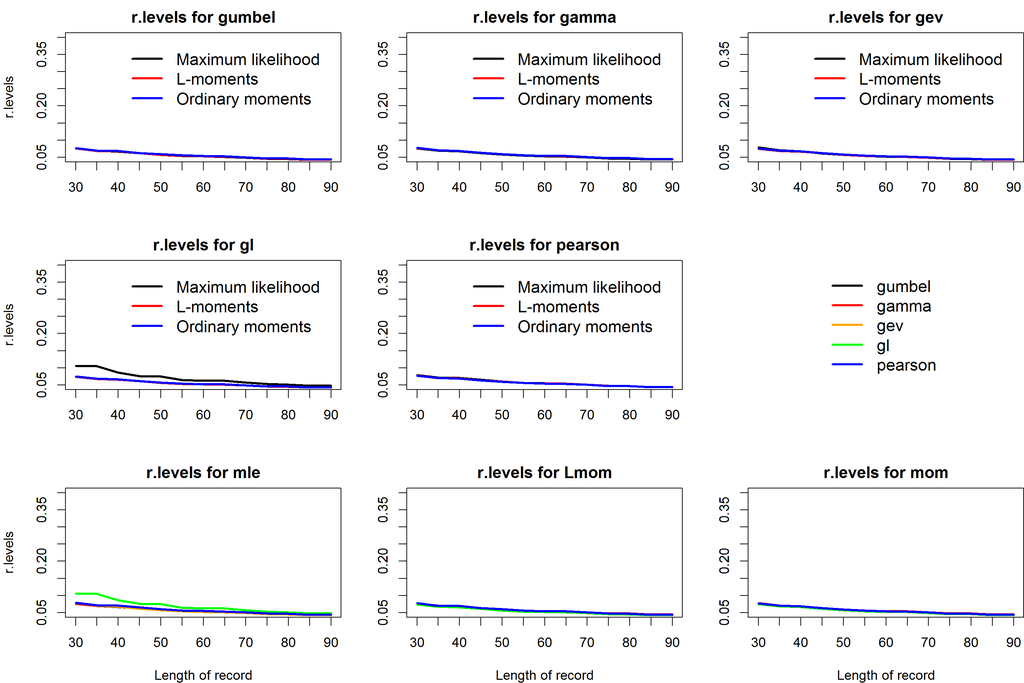

[1] “r.levels” [1] 10 [1] 14 19 22 28 29 31 32 33 41 44 59 60 61 62 63 64 65 [18] 66 67 68 69 74 75 78 80 81 82 83 84 85 88 91 92 93 [35] 94 96 97 102 103 105 106 107 108 109 110 112 125 126 127 128 130 [52] 132 133 134 136 138 140 141 142 145 147 157 163 165 171 179 182 185 [69] 201 204 216 220 227 262 279 283 291 [1] “done printint”

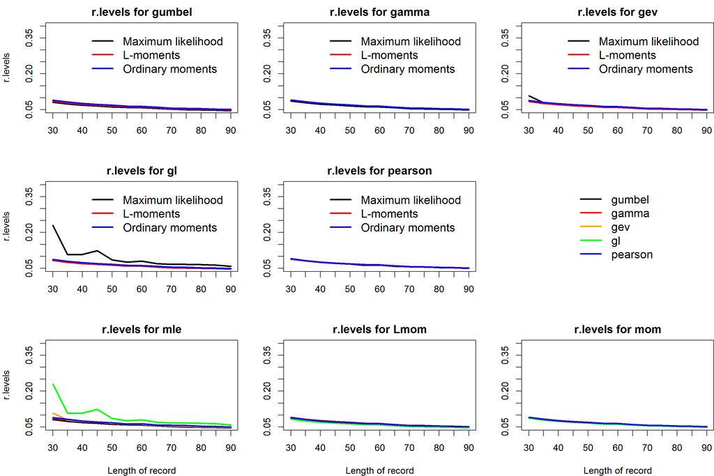

#### RL 100y

[1] “r.levels” [1] 100 [1] 10 11 12 13 16 17 18 20 21 25 38 39 43 49 50 57 77 [18] 116 117 144 149 152 153 160 161 168 174 180 188 189 202 203 208 214 [35] 222 231 233 234 235 237 240 242 244 245 246 247 251 252 254 256 289 [52] 298 [1] “done printint”

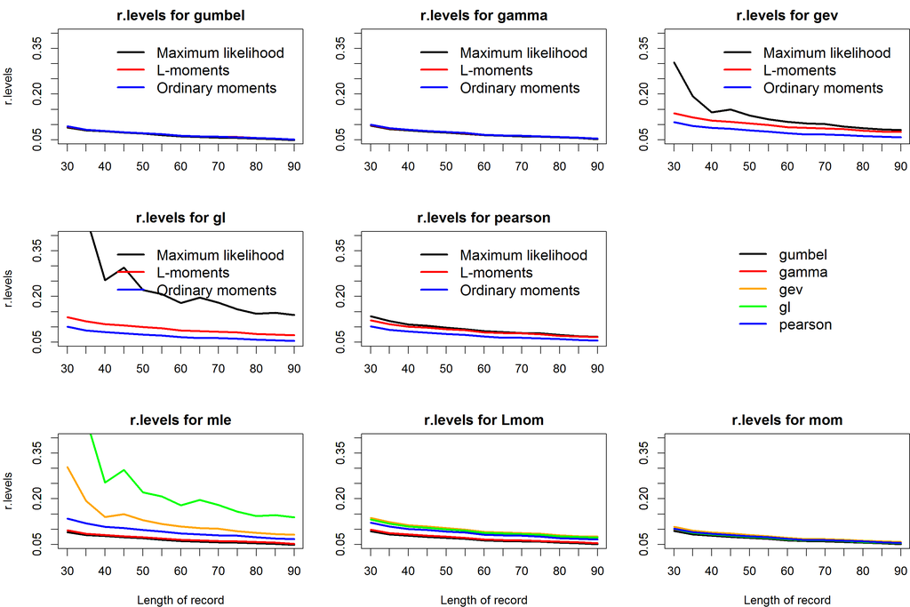

[1] “r.levels” [1] 100 [1] 1 15 23 27 34 40 42 45 46 56 58 111 119 120 121 122 123 [18] 124 150 156 164 166 175 176 197 224 229 230 288 290 [1] “done printint”

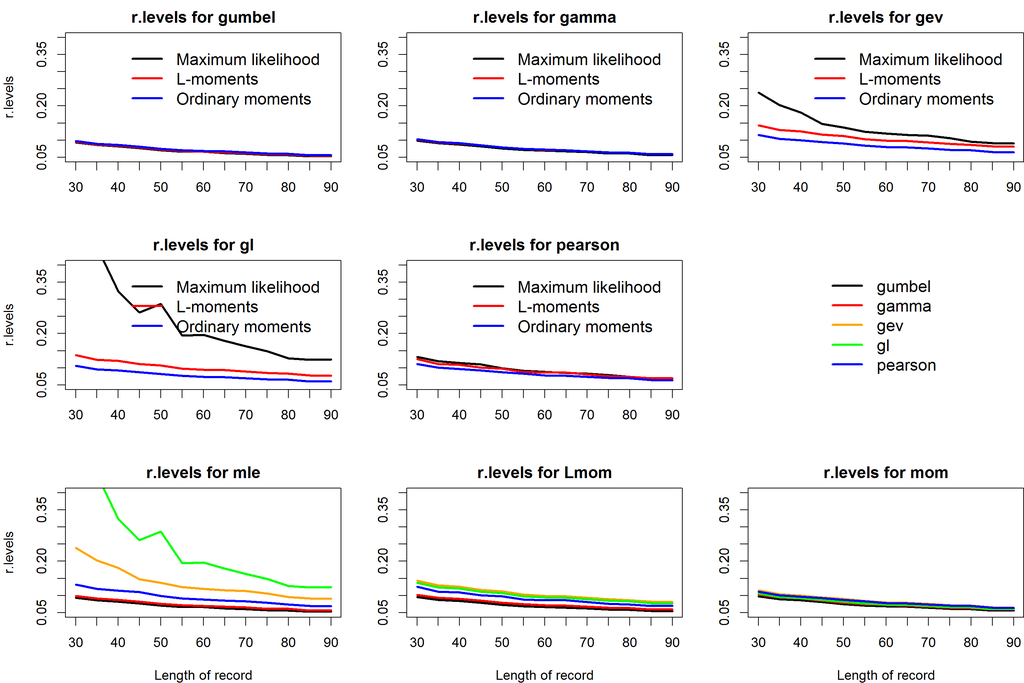

[1] “r.levels” [1] 100 [1] 14 19 22 28 29 31 32 33 41 44 59 60 61 62 63 64 65 [18] 66 67 68 69 74 75 78 80 81 82 83 84 85 88 91 92 93 [35] 94 96 97 102 103 105 106 107 108 109 110 112 125 126 127 128 130 [52] 132 133 134 136 138 140 141 142 145 147 157 163 165 171 179 182 185 [69] 201 204 216 220 227 262 279 283 291 [1] “done printint”

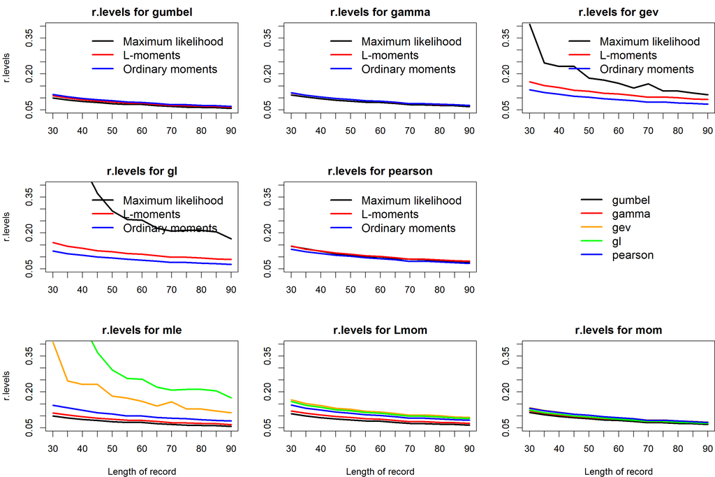

#### RL 200y

[1] “r.levels” [1] 200 [1] 10 11 12 13 16 17 18 20 21 25 38 39 43 49 50 57 77 [18] 116 117 144 149 152 153 160 161 168 174 180 188 189 202 203 208 214 [35] 222 231 233 234 235 237 240 242 244 245 246 247 251 252 254 256 289 [52] 298 [1] “done printint”

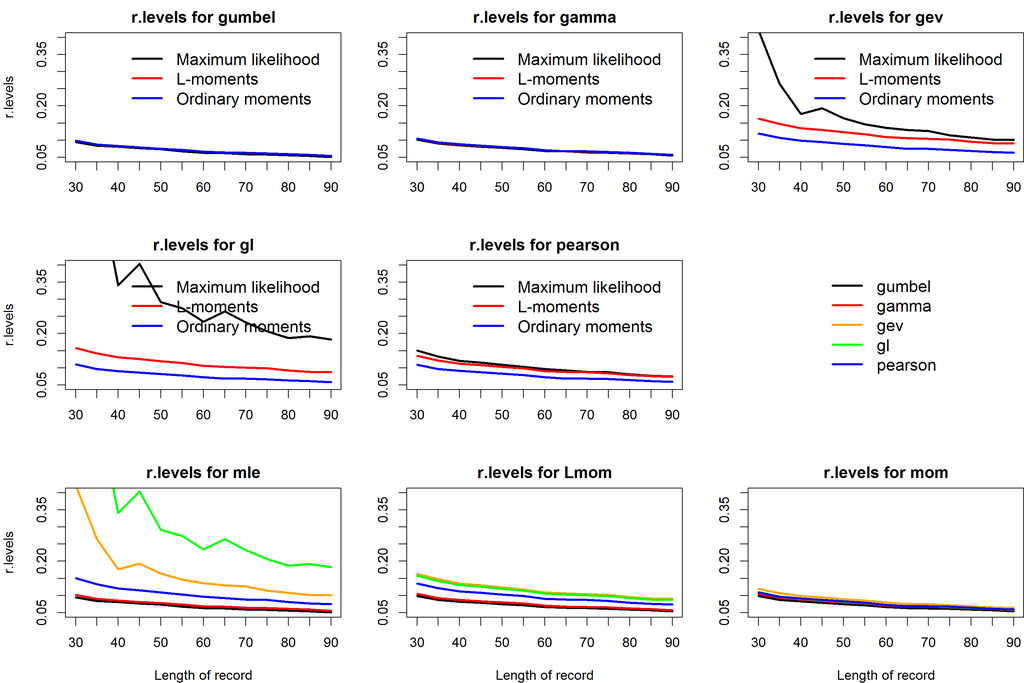

[1] “r.levels” [1] 200 [1] 1 15 23 27 34 40 42 45 46 56 58 111 119 120 121 122 123 [18] 124 150 156 164 166 175 176 197 224 229 230 288 290 [1] “done printint”

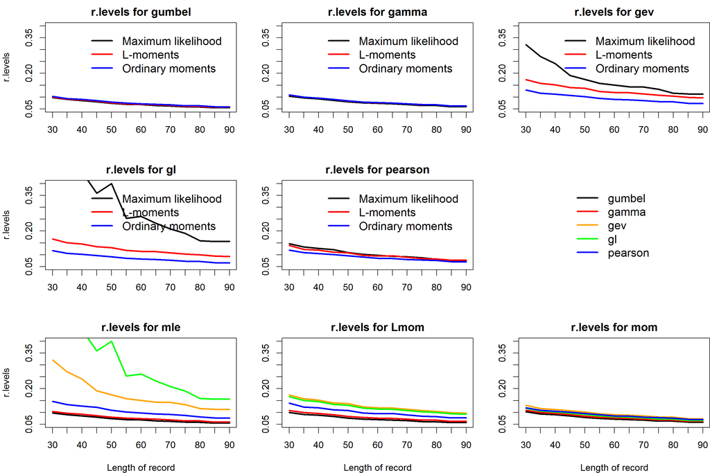

[1] “r.levels” [1] 200 [1] 14 19 22 28 29 31 32 33 41 44 59 60 61 62 63 64 65 [18] 66 67 68 69 74 75 78 80 81 82 83 84 85 88 91 92 93 [35] 94 96 97 102 103 105 106 107 108 109 110 112 125 126 127 128 130 [52] 132 133 134 136 138 140 141 142 145 147 157 163 165 171 179 182 185 [69] 201 204 216 220 227 262 279 283 291 [1] “done printint”

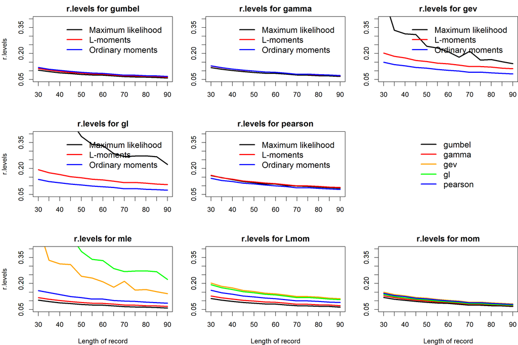

## KS

[1] 10 11 12 13 16 17 18 20 21 25 38 39 43 49 50 57 77 [18] 116 117 144 149 152 153 160 161 168 174 180 188 189 202 203 208 214 [35] 222 231 233 234 235 237 240 242 244 245 246 247 251 252 254 256 289 [52] 298 [1] “entered the plotting function” [1] 30 [1] 150

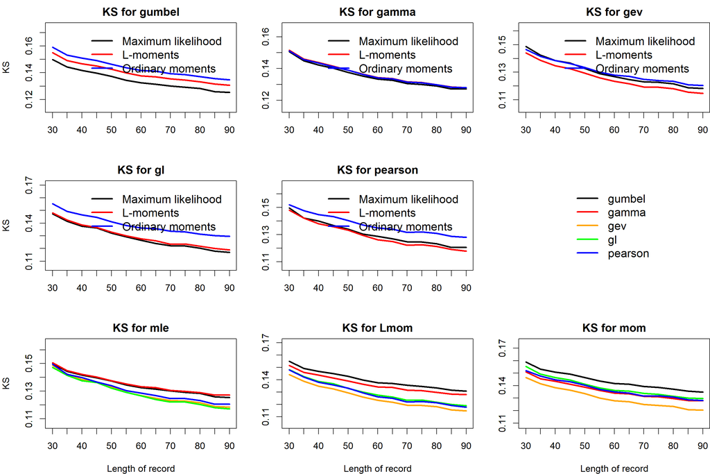

[1] 1 15 23 27 34 40 42 45 46 56 58 111 119 120 121 122 123 [18] 124 150 156 164 166 175 176 197 224 229 230 288 290 [1] “entered the plotting function” [1] 30 [1] 150

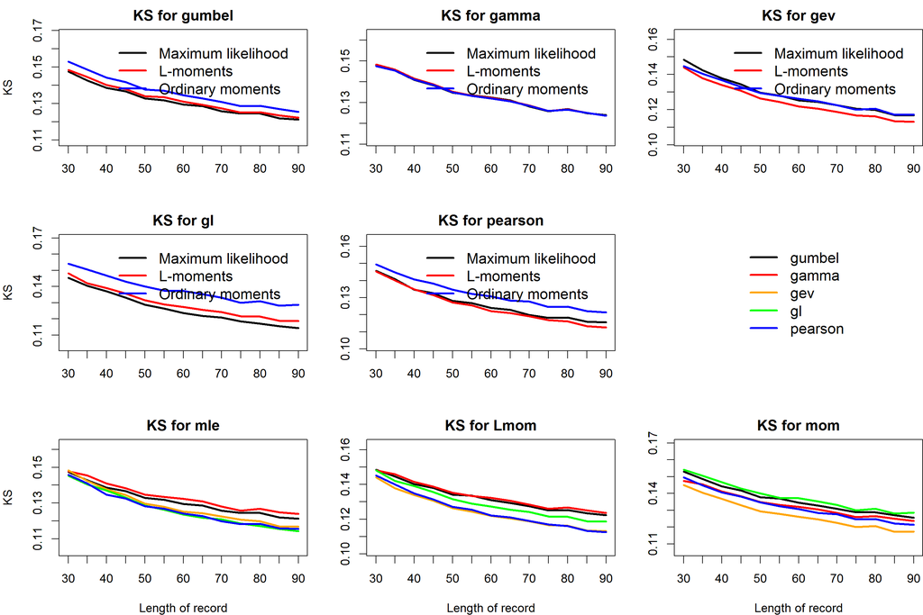

[1] 14 19 22 28 29 31 32 33 41 44 59 60 61 62 63 64 65 [18] 66 67 68 69 74 75 78 80 81 82 83 84 85 88 91 92 93 [35] 94 96 97 102 103 105 106 107 108 109 110 112 125 126 127 128 130 [52] 132 133 134 136 138 140 141 142 145 147 157 163 165 171 179 182 185 [69] 201 204 216 220 227 262 279 283 291 [1] “entered the plotting function” [1] 30 [1] 150

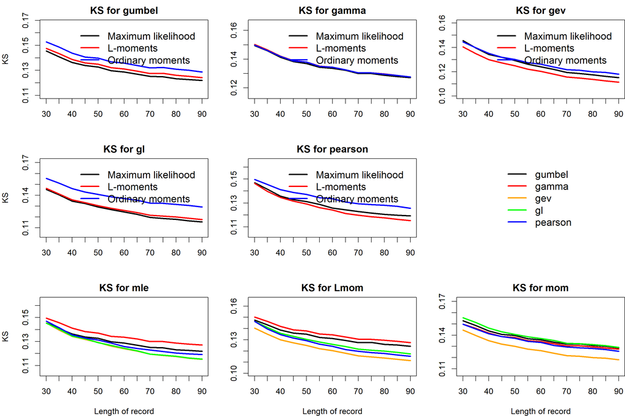

## AD

[1] 10 11 12 13 16 17 18 20 21 25 38 39 43 49 50 57 77 [18] 116 117 144 149 152 153 160 161 168 174 180 188 189 202 203 208 214 [35] 222 231 233 234 235 237 240 242 244 245 246 247 251 252 254 256 289 [52] 298 [1] “entered the plotting function” [1] 30 [1] 150

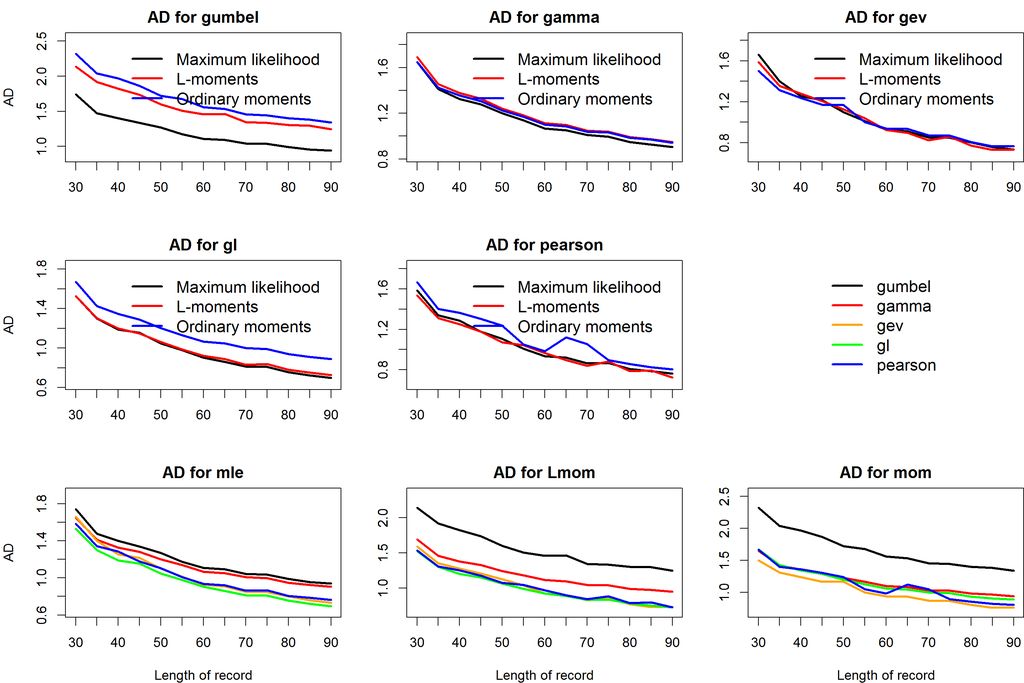

[1] 1 15 23 27 34 40 42 45 46 56 58 111 119 120 121 122 123 [18] 124 150 156 164 166 175 176 197 224 229 230 288 290 [1] “entered the plotting function” [1] 30 [1] 150

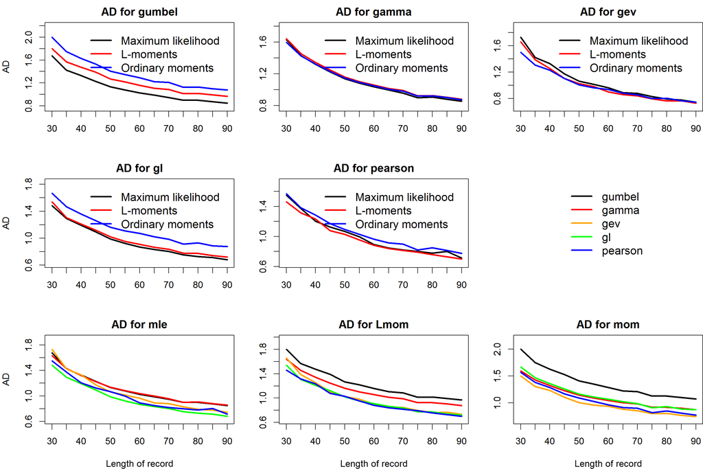

[1] 14 19 22 28 29 31 32 33 41 44 59 60 61 62 63 64 65 [18] 66 67 68 69 74 75 78 80 81 82 83 84 85 88 91 92 93 [35] 94 96 97 102 103 105 106 107 108 109 110 112 125 126 127 128 130 [52] 132 133 134 136 138 140 141 142 145 147 157 163 165 171 179 182 185 [69] 201 204 216 220 227 262 279 283 291 [1] “entered the plotting function” [1] 30 [1] 150

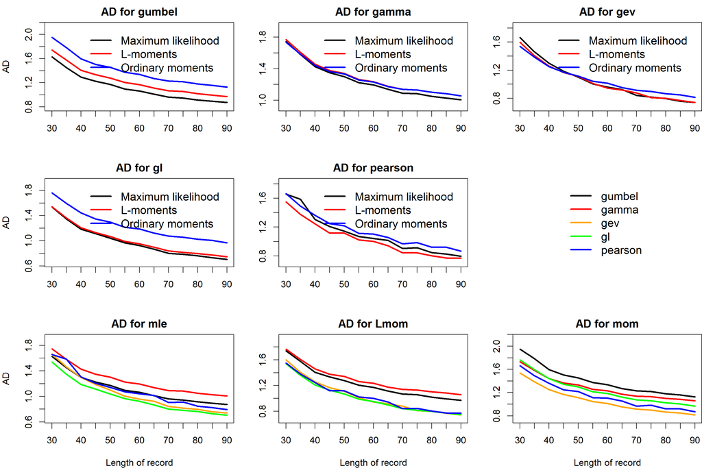